# IE582 Project

Burcu Çeştan - Nilgün Öztürk

2025-01-12

## 1. Introduction

### Problem Description

This project focuses on the dynamic and challenging domain of live sports betting. The main objective was to develop a strategy to predict soccer match outcomes—home win, draw, or away win—using real-time data such as in-game odds and match events. Additionally, the task required determining the optimal moments during a match to place bets, balancing prediction accuracy and profitability.

One of the key challenges in this task was accounting for the unpredictable nature of match events, such as goals, red cards, or substitutions, which can significantly impact game dynamics and betting odds. Moreover, the project was designed to reflect real-world constraints, ensuring that predictions were made without access to future information.

Building on the groundwork laid in Homework 2, where we analyzed and preprocessed the same dataset, this project applied advanced machine learning and data mining techniques. The ultimate goal was to create a robust framework for real-time predictions and decision-making, bridging theoretical approaches with practical applications in live sports betting.

### Descriptive Analysis of the Given Data

The dataset provided for this project included detailed information about football matches. Key columns included match outcomes (the target variable), betting odds for home wins (X1), away wins (X2), and draws (X), as well as team names, fixture IDs, and match statuses. Time-related data, such as the match’s start time and progression, was also included.

An initial review of the data showed significant differences in betting odds and match results across fixtures. The odds for home wins, away wins, and draws were particularly important because they reflected market expectations for each team’s performance. By comparing these odds with the actual results, we assessed how accurately the model captured patterns in the data and made predictions.

The data was cleaned by addressing missing values and converting betting odds into a numeric format. It was then split into training and test sets for evaluation. Basic statistics, such as the average and standard deviation of odds and match outcomes, were calculated to better understand the data before starting the model training process.

### Summary of the Proposed Approach

The approach proposed in this project involved training a machine learning model to predict the outcome of football matches based on betting odds and match-related statistics. The primary focus was on utilizing the odds for home win, away win, and draw as key features for classification. The dataset underwent preprocessing steps to handle missing values and ensure the data was in the proper format for model training.

Several classification models, including logistic regression, decision trees, and random forests, were applied to the dataset. To assess the models’ performance, cross-validation was employed, particularly focusing on metrics such as accuracy, precision, recall, and F1 score. The performance of the models was compared to determine which approach yielded the best results. A combination of feature engineering, model selection, and evaluation guided the development of a robust predictive system. The aim was to build a model that could generalize well to unseen match data and provide accurate predictions.

## 2. Related Literature

Štrumbelj [1] explains how betting odds can be adjusted to remove the bookmaker’s margin, making the probabilities more accurate. This is done by dividing each implied probability by the total of all probabilities. In our project, we used a similar method to improve the accuracy of our predictions.

Bunker and Thabtah [2] present a machine-learning framework for predicting sports outcomes, using data such as historical match results, player performance, and opposition metrics. The study highlights the application of Artificial Neural Networks (ANN) and discusses challenges like data quality and model evaluation, offering insights for improving sports predictions.

Meng [3] introduces a machine learning-based approach using Random Forest (RF) and Gradient Boosting (GB) to predict soccer match outcomes, with a focus on forecasting the results of the next World Cup. By training the model on historical tournament data, the study evaluates its performance based on precision and accuracy, concluding that RF outperforms GB in both metrics. The research also highlights the importance of identifying key features using feature importance scores, providing actionable insights for teams to improve performance.

In our project, we also tested multiple models, including Random Forest and XGBoost. Consistent with Meng’s findings, Random Forest outperformed Gradient Boosting in terms of both accuracy and total return. However, the best overall performance was achieved by Linear Discriminant Analysis (LDA), which demonstrated the highest accuracy (52.25%) and total return (132.86). These results highlight the effectiveness of LDA in sports analytics, while also confirming the competitive performance of Random Forest in comparison to Gradient Boosting.

## 3. Approach

### Background and Context

This project builds upon the foundational work conducted in Homework 2, where the soccer match dataset was initially analyzed, cleaned, and explored. Homework 2 allowed us to gain insights into the data structure, address missing values, and identify noisy data points. Building on this, the current project aims to develop a robust predictive model and implement an effective betting strategy.

A critical challenge addressed in this project was adhering to a real-world constraint: **making one prediction per match at a specific point in time (end of the first half)**. Once a prediction was made, no future information was used, ensuring that our approach was aligned with real-life betting scenarios and avoided “forward-seeing” errors.

### Data Preprocessing

#### 1. **Data Cleaning**

- Removed rows with matches marked as `suspended` or `stopped`, ensuring that only valid and completed games were analyzed.
- Calculated the percentage of missing values in each column and excluded columns with over 70% missing data.
- Applied imputation techniques to handle missing data:
  - **Numeric columns**: Filled missing values using the mean for symmetric distributions and the median for skewed distributions.
  - **Categorical columns**: Used the mode (most frequent value) to fill missing entries.

#### 2. **Noise Handling**

Specific noisy cases were identified and excluded to improve the data quality:

- **Goals in the First 10 Minutes**: Matches where early goals were scored were excluded, as these tend to disrupt the natural flow of the game.
- **Goals After the 85th Minute**: Late goals often result from defensive errors or aggressive attacks, which do not represent overall match competitiveness.
- **Unusual Events**: Matches with early substitutions (first 30 minutes), penalties in the first 15 minutes, or multiple yellow cards in the first 20 minutes were excluded, as these events skew the implied probabilities and distort game dynamics.

```
## Number of matches with a goal before 10 minutes:  549
```

```
## Number of matches with a goal after 85 minutes:  3168
```

```
## Number of matches with substitutions in the first 30 minutes:  700
```

```
## Number of matches with a penalty in the first 15 minutes:  93
```

```
## Number of matches with multiple yellow cards in the first 20 minutes:  157
```

#### 3. **Feature Engineering**

Several meaningful features were derived to enhance the predictive power of the models:

- **Derived Metrics**:
  - *Net Goal Difference*: Difference between goals scored by the home and away teams.
  - *Possession Imbalance*: Difference in possession percentages between the teams.
  - *Shot Effort Difference*: Difference in goal attempts by home and away teams.
- **Odds Transformation**:
  - Calculated implied probabilities from the odds for home win, draw, and away win.
  - Normalized the probabilities to ensure their sum equals 1.
- **Flag Variables**:
  - Created binary flags to capture significant match dynamics (e.g., possession dominance).

#### 4. **Decision Timing**

In line with the task requirements, predictions were limited to one decision per match, made at the **end of the first half**: - For both training and test datasets, data was filtered to focus only on the first half. - For each match, the **earliest available minute in the first half** was selected to ensure that predictions were based on data accessible up to that point. - This approach replicates real-world betting conditions, where future information (such as second-half events) is unavailable at the time of decision-making.

#### 5. **Data Splitting**

- Split the dataset into training and test sets based on the date:
  - Matches before November 2024 were used for training.
  - Matches from November 2024 onward were used for testing.
- Ensured that the training and test sets were mutually exclusive and that the feature distributions aligned.

### Model Development

To predict match outcomes (Home Win, Draw, Away Win), a range of machine learning models were explored. Each model was designed to optimize both predictive accuracy and profitability:

#### 1. **Decision Tree**

- Simple and interpretable model trained without and with cross-validation.
- Hyperparameter tuning was performed using a complexity parameter (cp) grid to balance underfitting and overfitting.

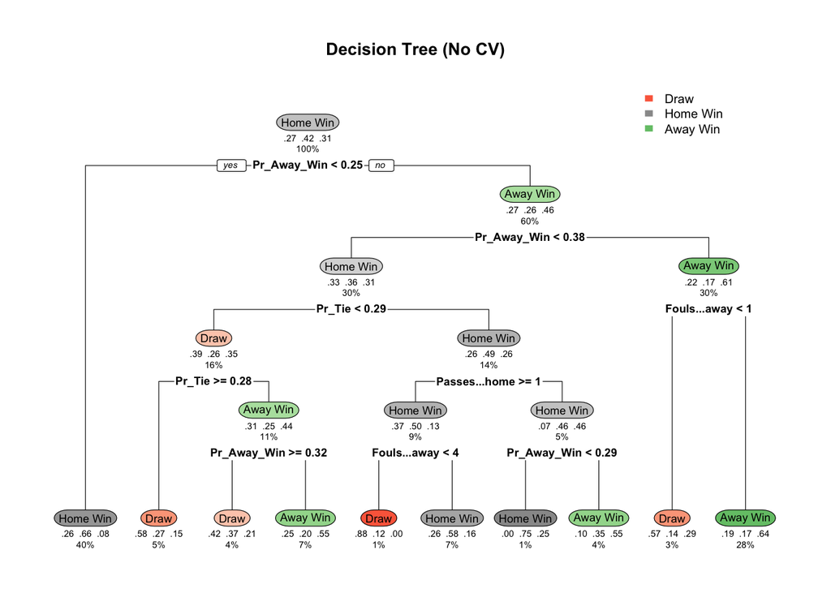

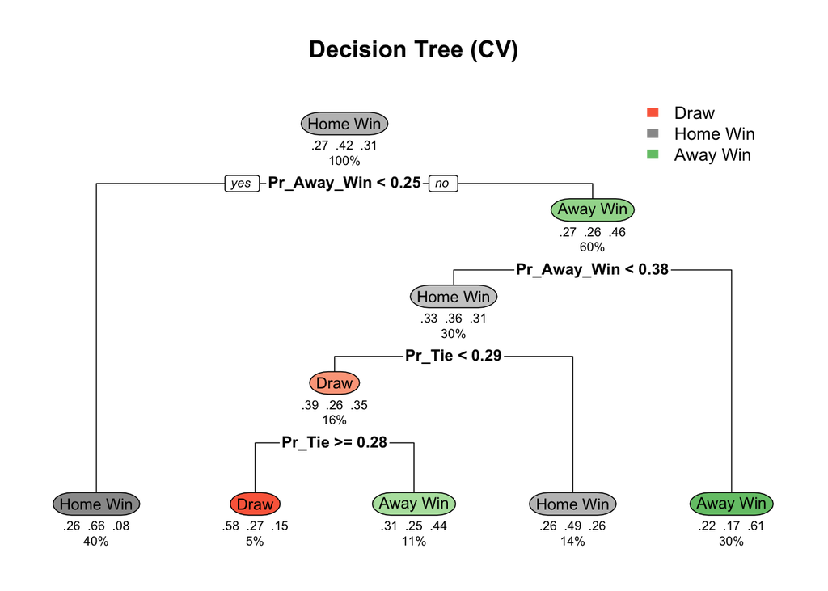

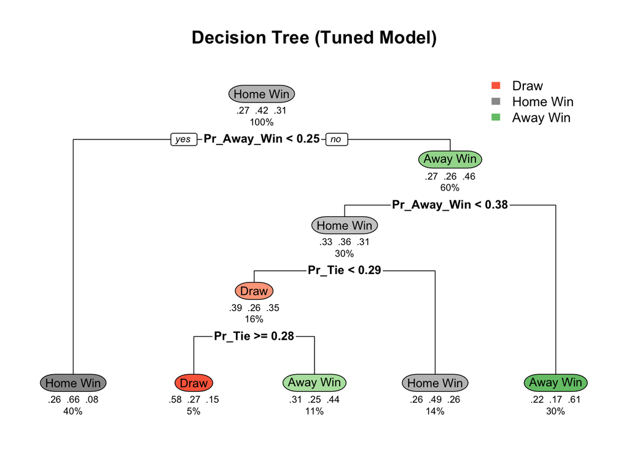

```
## Confusion Matrix for Decision Tree (No CV):
```

```
## Confusion Matrix and Statistics
##
##           Reference
## Prediction Draw Home Win Away Win
##   Draw        6        9        2
##   Home Win   10       30       11
##   Away Win    8       17       18
##
## Overall Statistics
##
##                Accuracy : 0.4865
##                  95% CI : (0.3905, 0.5832)
##     No Information Rate : 0.5045
##     P-Value [Acc > NIR] : 0.6824
##
##                   Kappa : 0.1809
##
##  Mcnemar's Test P-Value : 0.1764
##
## Statistics by Class:
##
##                      Class: Draw Class: Home Win Class: Away Win
## Sensitivity              0.25000          0.5357          0.5806
## Specificity              0.87356          0.6182          0.6875
## Pos Pred Value           0.35294          0.5882          0.4186
## Neg Pred Value           0.80851          0.5667          0.8088
## Prevalence               0.21622          0.5045          0.2793
## Detection Rate           0.05405          0.2703          0.1622
## Detection Prevalence     0.15315          0.4595          0.3874
## Balanced Accuracy        0.56178          0.5769          0.6341
```

```
## Confusion Matrix for Decision Tree (CV):
```

```
## Confusion Matrix and Statistics
##
##           Reference
## Prediction Draw Home Win Away Win
##   Draw        2        3        0
##   Home Win   11       32       13
##   Away Win   11       21       18
##
## Overall Statistics
##
##                Accuracy : 0.4685
##                  95% CI : (0.3731, 0.5655)
##     No Information Rate : 0.5045
##     P-Value [Acc > NIR] : 0.80350
##
##                   Kappa : 0.1285
##
##  Mcnemar's Test P-Value : 0.00057
##
## Statistics by Class:
##
##                      Class: Draw Class: Home Win Class: Away Win
## Sensitivity              0.08333          0.5714          0.5806
## Specificity              0.96552          0.5636          0.6000
## Pos Pred Value           0.40000          0.5714          0.3600
## Neg Pred Value           0.79245          0.5636          0.7869
## Prevalence               0.21622          0.5045          0.2793
## Detection Rate           0.01802          0.2883          0.1622
## Detection Prevalence     0.04505          0.5045          0.4505
## Balanced Accuracy        0.52443          0.5675          0.5903
```

```
## Confusion Matrix for Decision Tree (Tuned):
```

```
## Confusion Matrix and Statistics
##
##           Reference
## Prediction Draw Home Win Away Win
##   Draw        2        3        0
##   Home Win   11       32       13
##   Away Win   11       21       18
##
## Overall Statistics
##
##                Accuracy : 0.4685
##                  95% CI : (0.3731, 0.5655)
##     No Information Rate : 0.5045
##     P-Value [Acc > NIR] : 0.80350
##
##                   Kappa : 0.1285
##
##  Mcnemar's Test P-Value : 0.00057
##
## Statistics by Class:
##
##                      Class: Draw Class: Home Win Class: Away Win
## Sensitivity              0.08333          0.5714          0.5806
## Specificity              0.96552          0.5636          0.6000
## Pos Pred Value           0.40000          0.5714          0.3600
## Neg Pred Value           0.79245          0.5636          0.7869
## Prevalence               0.21622          0.5045          0.2793
## Detection Rate           0.01802          0.2883          0.1622
## Detection Prevalence     0.04505          0.5045          0.4505
## Balanced Accuracy        0.52443          0.5675          0.5903
```

```
## Comparison of Model Performance:
```

```
##                   Model  Accuracy Total_Return
## 1 Decision Tree (No CV) 0.4864865       115.75
## 2    Decision Tree (CV) 0.4684685       109.03
## 3 Decision Tree (Tuned) 0.4684685       109.03
```

#### 2. **Random Forest**

- Leveraged an ensemble of decision trees to improve robustness.
- Cross-validated to determine the optimal number of features (mtry) considered at each split.
- Variable importance was analyzed to identify the most significant features.

```
## Confusion Matrix for Random Forest (No CV):
```

```
## Confusion Matrix and Statistics
##
##           Reference
## Prediction Draw Home Win Away Win
##   Draw        6        6        4
##   Home Win   14       34       15
##   Away Win    4       16       12
##
## Overall Statistics
##
##                Accuracy : 0.4685
##                  95% CI : (0.3731, 0.5655)
##     No Information Rate : 0.5045
##     P-Value [Acc > NIR] : 0.8035
##
##                   Kappa : 0.117
##
##  Mcnemar's Test P-Value : 0.3572
##
## Statistics by Class:
##
##                      Class: Draw Class: Home Win Class: Away Win
## Sensitivity              0.25000          0.6071          0.3871
## Specificity              0.88506          0.4727          0.7500
## Pos Pred Value           0.37500          0.5397          0.3750
## Neg Pred Value           0.81053          0.5417          0.7595
## Prevalence               0.21622          0.5045          0.2793
## Detection Rate           0.05405          0.3063          0.1081
## Detection Prevalence     0.14414          0.5676          0.2883
## Balanced Accuracy        0.56753          0.5399          0.5685
```

```
## Confusion Matrix for Random Forest (CV):
```

```
## Confusion Matrix and Statistics
##
##           Reference
## Prediction Draw Home Win Away Win
##   Draw        4       11        6
##   Home Win   15       29       15
##   Away Win    5       16       10
##
## Overall Statistics
##
##                Accuracy : 0.3874
##                  95% CI : (0.2964, 0.4845)
##     No Information Rate : 0.5045
##     P-Value [Acc > NIR] : 0.9949
##
##                   Kappa : 5e-04
##
##  Mcnemar's Test P-Value : 0.8641
##
## Statistics by Class:
##
##                      Class: Draw Class: Home Win Class: Away Win
## Sensitivity              0.16667          0.5179         0.32258
## Specificity              0.80460          0.4545         0.73750
## Pos Pred Value           0.19048          0.4915         0.32258
## Neg Pred Value           0.77778          0.4808         0.73750
## Prevalence               0.21622          0.5045         0.27928
## Detection Rate           0.03604          0.2613         0.09009
## Detection Prevalence     0.18919          0.5315         0.27928
## Balanced Accuracy        0.48563          0.4862         0.53004
```

```
## Comparison of Random Forest Model Performance:
```

```
##                   Model  Accuracy Total_Return
## 1 Random Forest (No CV) 0.4684685       110.98
## 2    Random Forest (CV) 0.3873874        76.95
```

#### 3. **Multinomial Logistic Regression**

- Regularized using penalized regression (ridge penalty) to prevent overfitting.
- Cross-validation was performed to optimize the decay parameter.

```
## Confusion Matrix for Multinomial Logistic Regression (No CV):
```

```
## Confusion Matrix and Statistics
##
##           Reference
## Prediction Draw Home Win Away Win
##   Draw        8       19        8
##   Home Win    5       12        5
##   Away Win   11       25       18
##
## Overall Statistics
##
##                Accuracy : 0.3423
##                  95% CI : (0.2549, 0.4384)
##     No Information Rate : 0.5045
##     P-Value [Acc > NIR] : 0.9998
##
##                   Kappa : 0.055
##
##  Mcnemar's Test P-Value : 6.606e-05
##
## Statistics by Class:
##
##                      Class: Draw Class: Home Win Class: Away Win
## Sensitivity              0.33333          0.2143          0.5806
## Specificity              0.68966          0.8182          0.5500
## Pos Pred Value           0.22857          0.5455          0.3333
## Neg Pred Value           0.78947          0.5056          0.7719
## Prevalence               0.21622          0.5045          0.2793
## Detection Rate           0.07207          0.1081          0.1622
## Detection Prevalence     0.31532          0.1982          0.4865
## Balanced Accuracy        0.51149          0.5162          0.5653
```

```
## Confusion Matrix for Multinomial Logistic Regression (CV):
```

```
## Confusion Matrix and Statistics
##
##           Reference
## Prediction Draw Home Win Away Win
##   Draw        6       12        5
##   Home Win    9       23       10
##   Away Win    9       21       16
##
## Overall Statistics
##
##                Accuracy : 0.4054
##                  95% CI : (0.3132, 0.5027)
##     No Information Rate : 0.5045
##     P-Value [Acc > NIR] : 0.9857
##
##                   Kappa : 0.0832
##
##  Mcnemar's Test P-Value : 0.1402
##
## Statistics by Class:
##
##                      Class: Draw Class: Home Win Class: Away Win
## Sensitivity              0.25000          0.4107          0.5161
## Specificity              0.80460          0.6545          0.6250
## Pos Pred Value           0.26087          0.5476          0.3478
## Neg Pred Value           0.79545          0.5217          0.7692
## Prevalence               0.21622          0.5045          0.2793
## Detection Rate           0.05405          0.2072          0.1441
## Detection Prevalence     0.20721          0.3784          0.4144
## Balanced Accuracy        0.52730          0.5326          0.5706
```

```
## Comparison of Multinomial Logistic Regression Model Performance:
```

```
##                                     Model  Accuracy Total_Return
## 1 Multinomial Logistic Regression (No CV) 0.3423423        46.12
## 2    Multinomial Logistic Regression (CV) 0.4054054        82.38
```

#### 4. **Linear Discriminant Analysis (LDA)**

- Applied to reduce dimensionality and optimize class separation.
- Addressed collinearity issues by removing constant and highly correlated variables.

```
## Confusion Matrix for LDA (No CV):
```

```
## Confusion Matrix and Statistics
##
##           Reference
## Prediction Draw Home Win Away Win
##   Draw        0        0        0
##   Home Win   21       50       27
##   Away Win    3        6        4
##
## Overall Statistics
##
##                Accuracy : 0.4865
##                  95% CI : (0.3905, 0.5832)
##     No Information Rate : 0.5045
##     P-Value [Acc > NIR] : 0.6824
##
##                   Kappa : 0.016
##
##  Mcnemar's Test P-Value : 3.854e-08
##
## Statistics by Class:
##
##                      Class: Draw Class: Home Win Class: Away Win
## Sensitivity               0.0000          0.8929         0.12903
## Specificity               1.0000          0.1273         0.88750
## Pos Pred Value               NaN          0.5102         0.30769
## Neg Pred Value            0.7838          0.5385         0.72449
## Prevalence                0.2162          0.5045         0.27928
## Detection Rate            0.0000          0.4505         0.03604
## Detection Prevalence      0.0000          0.8829         0.11712
## Balanced Accuracy         0.5000          0.5101         0.50827
```

```
## Confusion Matrix for LDA (CV):
```

```
## Confusion Matrix and Statistics
##
##           Reference
## Prediction Draw Home Win Away Win
##   Draw        0        0        0
##   Home Win   21       48       21
##   Away Win    3        8       10
##
## Overall Statistics
##
##                Accuracy : 0.5225
##                  95% CI : (0.4256, 0.6182)
##     No Information Rate : 0.5045
##     P-Value [Acc > NIR] : 0.3881
##
##                   Kappa : 0.1127
##
##  Mcnemar's Test P-Value : 1.5e-06
##
## Statistics by Class:
##
##                      Class: Draw Class: Home Win Class: Away Win
## Sensitivity               0.0000          0.8571         0.32258
## Specificity               1.0000          0.2364         0.86250
## Pos Pred Value               NaN          0.5333         0.47619
## Neg Pred Value            0.7838          0.6190         0.76667
## Prevalence                0.2162          0.5045         0.27928
## Detection Rate            0.0000          0.4324         0.09009
## Detection Prevalence      0.0000          0.8108         0.18919
## Balanced Accuracy         0.5000          0.5468         0.59254
```

```
## Comparison of LDA Model Performance:
```

```
##         Model  Accuracy Total_Return
## 1 LDA (No CV) 0.4864865       120.46
## 2    LDA (CV) 0.5225225       132.86
```

#### 5. **Support Vector Machine (SVM)**

- Used a radial basis function (RBF) kernel to capture non-linear decision boundaries.
- Though computationally expensive, provided an alternative to tree-based models.

```
## Confusion Matrix for SVM (No CV):
```

```
## Confusion Matrix and Statistics
##
##           Reference
## Prediction Draw Home Win Away Win
##   Draw        2        3        1
##   Home Win   16       39       27
##   Away Win    6       14        3
##
## Overall Statistics
##
##                Accuracy : 0.3964
##                  95% CI : (0.3048, 0.4937)
##     No Information Rate : 0.5045
##     P-Value [Acc > NIR] : 0.9913443
##
##                   Kappa : -0.0822
##
##  Mcnemar's Test P-Value : 0.0008589
##
## Statistics by Class:
##
##                      Class: Draw Class: Home Win Class: Away Win
## Sensitivity              0.08333          0.6964         0.09677
## Specificity              0.95402          0.2182         0.75000
## Pos Pred Value           0.33333          0.4756         0.13043
## Neg Pred Value           0.79048          0.4138         0.68182
## Prevalence               0.21622          0.5045         0.27928
## Detection Rate           0.01802          0.3514         0.02703
## Detection Prevalence     0.05405          0.7387         0.20721
## Balanced Accuracy        0.51868          0.4573         0.42339
```

```
## Performance of SVM Model:
```

```
##         Model  Accuracy Total_Return
## 1 SVM (No CV) 0.3963964        75.76
```

**Note on Cross-Validation for SVM** During the implementation phase, we attempted to apply cross-validation (CV) for the SVM model using the caret package. However, due to incompatibilities in parameter tuning and runtime constraints with the e1071 library, we were unable to successfully train the SVM model with CV. As a result, we proceeded with a standard implementation of SVM without CV.

#### 6. **XGBoost**

- Gradient boosting algorithm configured for multi-class classification.
- Tuned hyperparameters (e.g., number of rounds) to optimize performance.

```
## Confusion Matrix for XGBoost:
```

```
## Confusion Matrix and Statistics
##
##           Reference
## Prediction Draw Home Win Away Win
##   Draw        6       10        6
##   Home Win   12       30       14
##   Away Win    6       16       11
##
## Overall Statistics
##
##                Accuracy : 0.4234
##                  95% CI : (0.3302, 0.5208)
##     No Information Rate : 0.5045
##     P-Value [Acc > NIR] : 0.9645
##
##                   Kappa : 0.0694
##
##  Mcnemar's Test P-Value : 0.9572
##
## Statistics by Class:
##
##                      Class: Draw Class: Home Win Class: Away Win
## Sensitivity              0.25000          0.5357          0.3548
## Specificity              0.81609          0.5273          0.7250
## Pos Pred Value           0.27273          0.5357          0.3333
## Neg Pred Value           0.79775          0.5273          0.7436
## Prevalence               0.21622          0.5045          0.2793
## Detection Rate           0.05405          0.2703          0.0991
## Detection Prevalence     0.19820          0.5045          0.2973
## Balanced Accuracy        0.53305          0.5315          0.5399
```

```
## Performance of XGBoost Model:
```

```
##     Model  Accuracy Total_Return
## 1 XGBoost 0.4234234           90
```

### Evaluation and Metrics

Each model was evaluated on both predictive and financial metrics:

1. **Accuracy**: Proportion of correctly predicted match outcomes.
2. **Profitability**: Total returns from bets placed based on model predictions.
3. **Confusion Matrix Metrics**:
   - Precision, Recall, and F1 Score for each class (Home Win, Draw, Away Win).
4. **Balanced Metrics**: Considered sensitivity and specificity to address class imbalance issues.

### Comparison of Results

The models were compared based on accuracy and total return. Key findings include:

- **LDA** achieved the highest accuracy (52.25%) and profitability (132.86).
- **Decision Tree** demonstrated consistent performance across training and cross-validation, offering a balance between simplicity and profitability.
- **Random Forest** and **XGBoost** highlighted the value of ensemble methods, though at a higher computational cost.
- While **SVM** and **Multinomial Logistic Regression** showed moderate accuracy, their profitability was lower compared to LDA and Decision Tree.

This approach demonstrates a comprehensive methodology for predicting soccer match outcomes and formulating an effective betting strategy. By focusing on early decision-making (end of the first half) and leveraging advanced machine learning techniques, we ensured that predictions were aligned with real-world constraints. The project highlights the trade-offs between model complexity, accuracy, and financial returns, providing a robust framework for decision-making in betting scenarios.

## 4.Results

In this section, we present the results of the models applied to the soccer match outcome prediction task. The models are evaluated based on two main metrics:

- **Accuracy:** The proportion of correct predictions made by the model.
- **Total Return:** The profitability of the betting strategy based on the model’s predictions.

The results of the models are summarized in the table below:

```
##                                      Model  Accuracy Total_Return
## 1                    Decision Tree (No CV) 0.4864865       115.75
## 2                       Decision Tree (CV) 0.4684685       109.03
## 3                    Decision Tree (Tuned) 0.4684685       109.03
## 4                    Random Forest (No CV) 0.4684685       110.98
## 5                       Random Forest (CV) 0.3873874        76.95
## 6  Multinomial Logistic Regression (No CV) 0.3423423        46.12
## 7     Multinomial Logistic Regression (CV) 0.4054054        82.38
## 8                              LDA (No CV) 0.4864865       120.46
## 9                                 LDA (CV) 0.5225225       132.86
## 10                             SVM (No CV) 0.3963964        75.76
## 11                         XGBoost (No CV) 0.4234234        90.00
```

### Discussion

**LDA Models:** The LDA models were the most effective, both in terms of accuracy and profitability. The cross-validated version achieved the highest accuracy of 0.5225 and a total return of 132.86. The non-cross-validated version performed well too, with an accuracy of 0.4865 and a return of 120.46. These results suggest that LDA was the most successful model in terms of both prediction accuracy and profitability.

**SVM and XGBoost Models:** Both SVM and XGBoost models performed poorly compared to other models. The SVM model achieved an accuracy of 0.3964 and a return of 75.76, while XGBoost showed a slightly better performance with an accuracy of 0.4234 and a return of 90.00. Both models underperformed in comparison to decision trees and LDA.

## 5.Conclusions and Future Work

In this project, we focused on predicting football match outcomes (home win, draw, or away win) using real-time match data and betting odds. Several machine learning models were evaluated, including Decision Trees, Random Forest, Multinomial Logistic Regression, LDA, Support Vector Machines (SVM), and XGBoost. Our findings indicated that while some models, such as the LDA and Decision Tree models, showed competitive performance, others like Random Forest and Multinomial Logistic Regression performed less effectively. Cross-validation was applied where possible, but it did not always improve model performance significantly.

### Possible Extensions for Future Work

There are several ways in which this approach could be improved for more accurate and profitable predictions:

- **Neural Networks:** Neural networks could be explored to capture non-linear patterns and improve prediction accuracy, particularly given their success in similar sports prediction tasks.
- **Feature Engineering:** Developing new features, such as player statistics, team form, or in-game events (e.g., goals, injuries), could enhance the model’s ability to capture game dynamics that affect match outcomes and betting odds.
- **Time-Series Models:** Since betting odds and match events are dynamic over time, applying time-series models like Long Short-Term Memory (LSTM) networks could better capture temporal dependencies in the data.
- **Ensemble Methods:** Further investigation into ensemble methods, such as stacking different models or combining predictions using weighted averages, might lead to improved accuracy and profitability.
- **Real-Time Betting Strategy:** Developing a real-time betting strategy that considers live game events and continuously adjusts predictions as new data becomes available could further optimize outcomes, especially in live betting scenarios.

By addressing these areas in future work, it’s possible to build a more robust framework for live sports betting predictions, combining predictive accuracy with profitability.

## 6.Code

The code for all six models used in this project (Decision Tree, Random Forest, Multinomial Logistic Regression, LDA, SVM, and XGBoost) can be accessed through the provided GitHub link:

[GitHub Repository](https://github.com/BU-IE-582/fall-24-burcucestan-boun/tree/main/IE582Project)

## 7. References

[1] E. Štrumbelj, “On determining probability forecasts from betting odds,” International Journal of Forecasting, vol. 30, no. 4, pp. 934–943, 2014. [Online]. Available: https://www.researchgate.net/publication/264349990_On_determining_probability_forecasts_from_betting_odds

[2] R. P. Bunker and F. Thabtah, “A machine learning framework for sport result prediction,” Applied Computing and Informatics, vol. 15, pp. 27–33, 2019. [Online]. Available: https://www.sciencedirect.com/science/article/pii/S2210832717301485

[3] X. Meng, “Soccer match outcome prediction with random forest and gradient boosting models,” Applied and Computational Engineering, vol. 40, pp. 99–107, Feb. 2024, doi: https://doi.org/10.54254/2755-2721/40/20230634

This project assignment includes assistance from ChatGPT for generating ideas, problem-solving approaches, and explanations related to the tasks. We ensured that the final implementation and coding were completed by us in alignment with the course’s academic integrity guidelines.